# CDC Daily by State

davegoblue

2/20/2022

## Background

This file is designed to use CDC data to assess coronavirus disease burden by state, including creating and analyzing state-level clusters.

Through March 7, 2021, [The COVID Tracking Project](https://covidtracking.com/) collected and integrated data on tests, cases, hospitalizations, deaths, and the like by state and date. The latest code for using this data is available in Coronavirus_Statistics_CTP_v004.Rmd.

The COVID Tracking Project suggest that [US federal data sources](https://covidtracking.com/analysis-updates/federal-covid-data-101-how-to-find-data) are now sufficiently robust to be used for analyses that previously relied on COVID Tracking Project. This code is an attempt to update modules in Coronavirus_Statistics_CTP_v004.Rmd to leverage US federal data.

The code in this module builds on code available in _v003, with function and mapping files updated:

- Generic_Added_Utility_Functions_202105_v001.R - generic functions that can be used in other areas
- Coronavirus_CDC_Daily_Functions_v001.R - functions specific to coronavirus daily data

Broadly, the CDC data analyzed by this module includes:

- CDC case and death data by state and date are available for download on the [CDC website](https://data.cdc.gov/api/views/9mfq-cb36/rows.csv?accessType=DOWNLOAD)
- CDC hospital data are available for download on the [healthdata.gov website](https://beta.healthdata.gov/api/views/g62h-syeh/rows.csv?accessType=DOWNLOAD)
- CDC vaccines data are also available for download on the [CDC website](https://data.cdc.gov/api/views/unsk-b7fc/rows.csv?accessType=DOWNLOAD):

## Functions and Mapping Files

The tidyverse package is loaded and functions are sourced:

```r
# The tidyverse functions are routinely used without package::function format
library(tidyverse)
# Functions are available in source file
source("./Generic_Added_Utility_Functions_202105_v001.R")
source("./Coronavirus_CDC_Daily_Functions_v001.R")
```

A series of mapping files are also available to allow for parameterized processing. Mappings include:

- urlMapper - mapping file for urlType and url location to download data
- renMapper - mapping file for renaming of variables in the raw data file
- selfListMapper - mapping file for transformations by variable type
- fullListMapper - mapping file for transformations across variable types
- lstComboMapper - mapping file for elements to be combined by data type (most common is to combine NYC and NYS data to NY if the file provides them separately)
- uqMapper - mapping file for fields that should combine to be unique keys for processed files
- lstFilterMapper - mapping file for filtering to subset (most common is to keep 50 states and DC)
- vecSelectMapper - mapping file for variables to keep
- checkControlGroupMapper - mapping file for group_by() of control total checks
- checkControlAggMapper - mapping file for numeric variables for control total checks
- checkSimilarityMapper - mapping file for similarity checks to perform
- plotSimilarityMaooer - mapping file for fields where differences in universe should be plotted
- keyAggMapper - mapping file for the aggregate-level control total checks to perform
- perCapMapper - named vector that drives conversion from original field name to per capita field name
- hhsMapper - named vector that drivers numerical variables to keep (and renaming) from HHS capacity data file

These default parameters are maintained in a separate .R file and can be sourced:

```r
source("./Coronavirus_CDC_Daily_Default_Mappings_v002.R")
```

## Example Code Processing

The function is run to download and process the latest CDC case, hospitalization, and death data:

```
##
## *** File has been checked for uniqueness by: state date
```

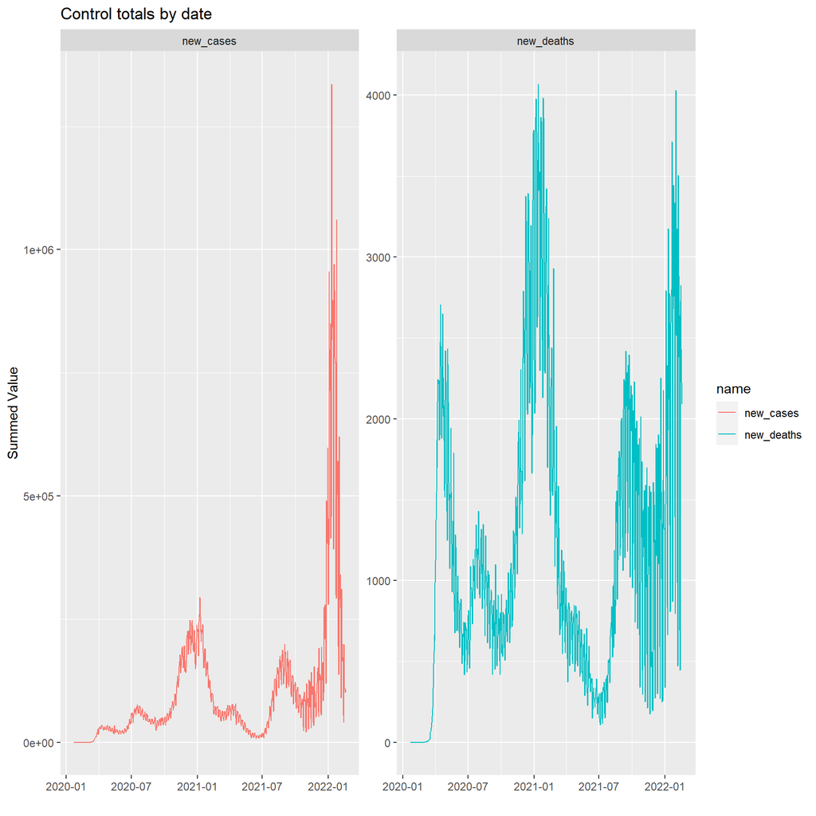

```
##
##
## Checking for similarity of: column names
## In reference but not in current:
## In current but not in reference:
##
## Checking for similarity of: date
## In reference but not in current: 0
## In current but not in reference: 14
##
## Checking for similarity of: state
## In reference but not in current:
## In current but not in reference:
```

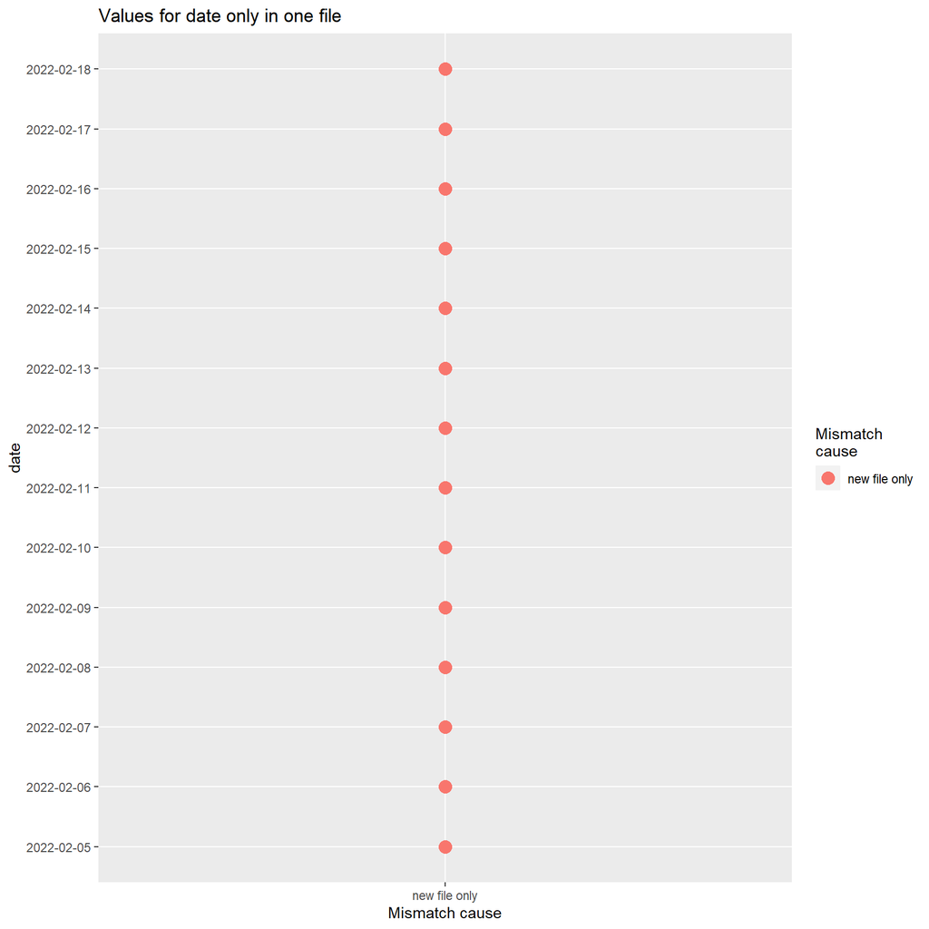

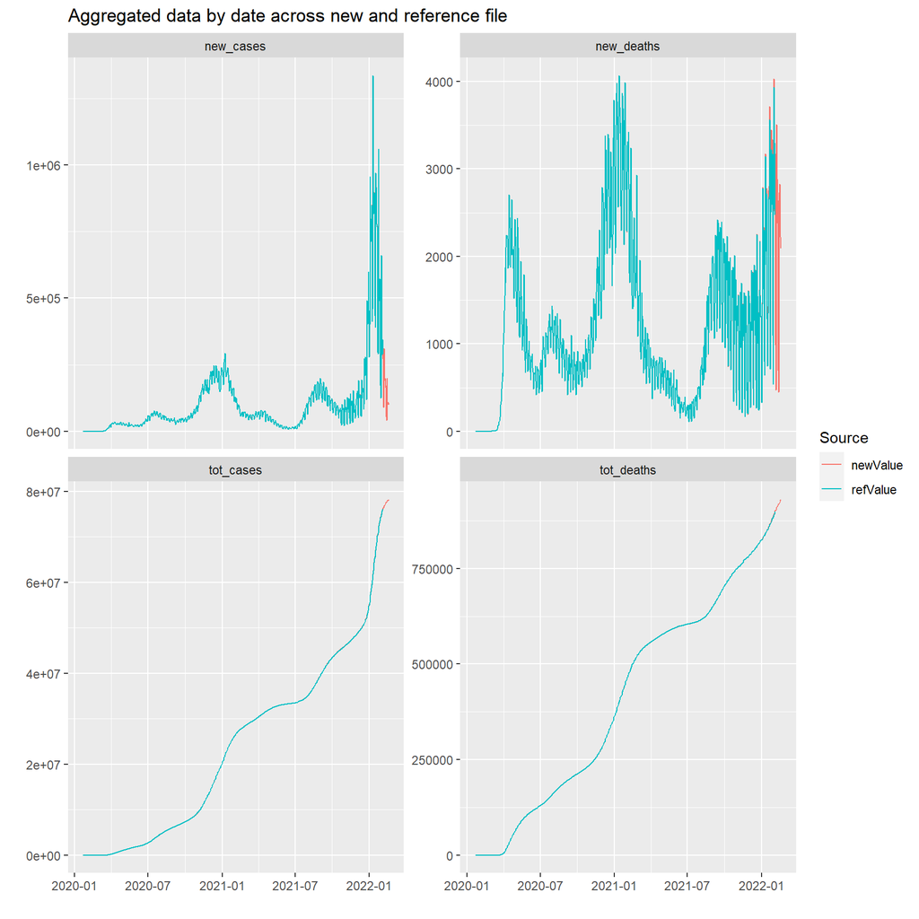

```
##
##
## ***Differences of at least 5 and at least 5%
##
##          date       name newValue refValue absDelta   pctDelta
## 1  2022-01-30 new_deaths      796      539      257 0.38501873
## 2  2022-01-29 new_deaths     1394     1098      296 0.23756019
## 3  2022-01-23 new_deaths      868      709      159 0.20164870
## 4  2022-01-22 new_deaths     1176     1028      148 0.13430127
## 5  2022-01-16 new_deaths      807      747       60 0.07722008
## 6  2022-01-25 new_deaths     3445     3220      225 0.06751688
## 7  2022-01-24 new_deaths     2679     2505      174 0.06712963
## 8  2022-01-27 new_deaths     2757     2592      165 0.06169377
## 9  2022-01-17 new_deaths     1429     1350       79 0.05685498
## 10 2022-01-26 new_deaths     3023     2858      165 0.05611291
## 11 2022-01-29  new_cases   195076   173891    21185 0.11483412
## 12 2022-01-30  new_cases   138089   124992    13097 0.09956629
## 13 2022-01-31  new_cases   620416   661083    40667 0.06346786
## 14 2022-02-04  new_cases   272825   289747    16922 0.06015941
```

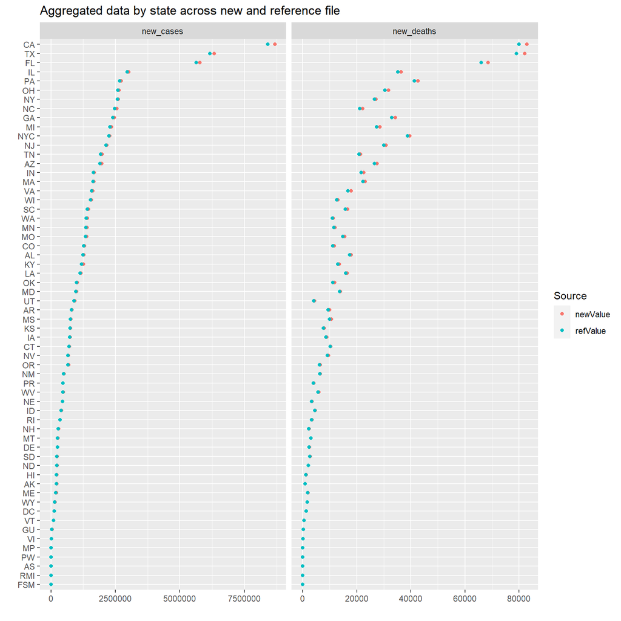

```
##
##
## ***Differences of at least 0 and at least 0.1%
##
##    state       name   newValue   refValue absDelta    pctDelta
## 1     KY tot_deaths    4003629    3992287    11342 0.002836948
## 2     AL tot_deaths    5972978    5963555     9423 0.001578850
## 3     NC tot_deaths    6808527    6798521    10006 0.001470708
## 4     FL  tot_cases 1290393798 1286243847  4149951 0.003221214
## 5     MD  tot_cases  232491171  231793719   697452 0.003004414
## 6     KY  tot_cases  252489934  252077588   412346 0.001634453
## 7     FL new_deaths      68042      66007     2035 0.030362032
## 8     KY new_deaths      13402      13063      339 0.025618742
## 9     AL new_deaths      17741      17371      370 0.021075416
## 10    NC new_deaths      21278      21097      181 0.008542773
```

[output cut: 30 more lines]

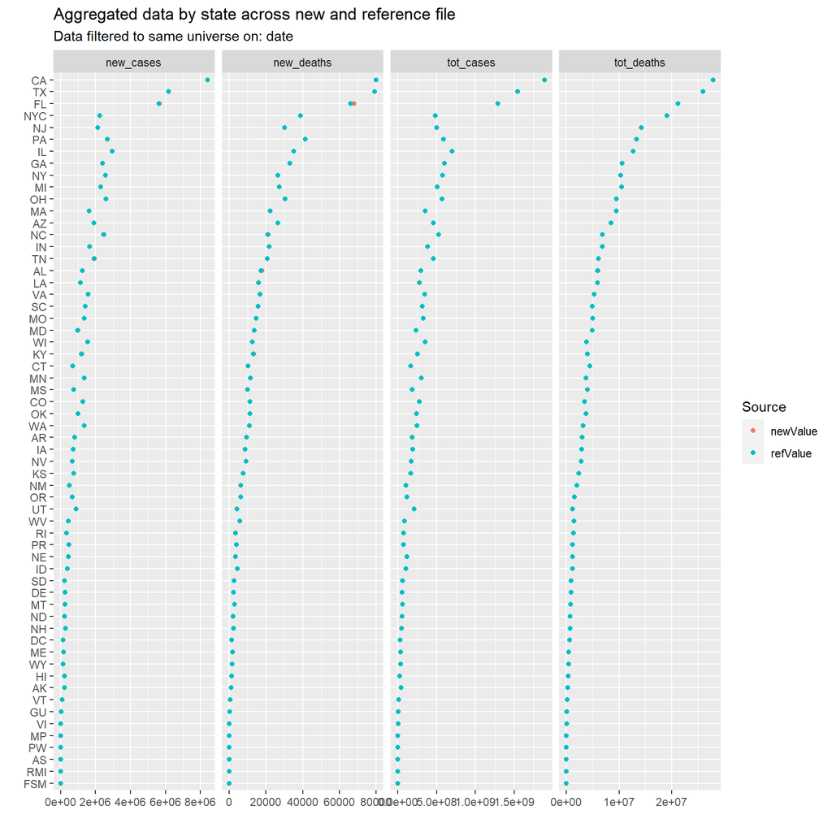

```
##
## *** File has been checked for uniqueness by: state date
```

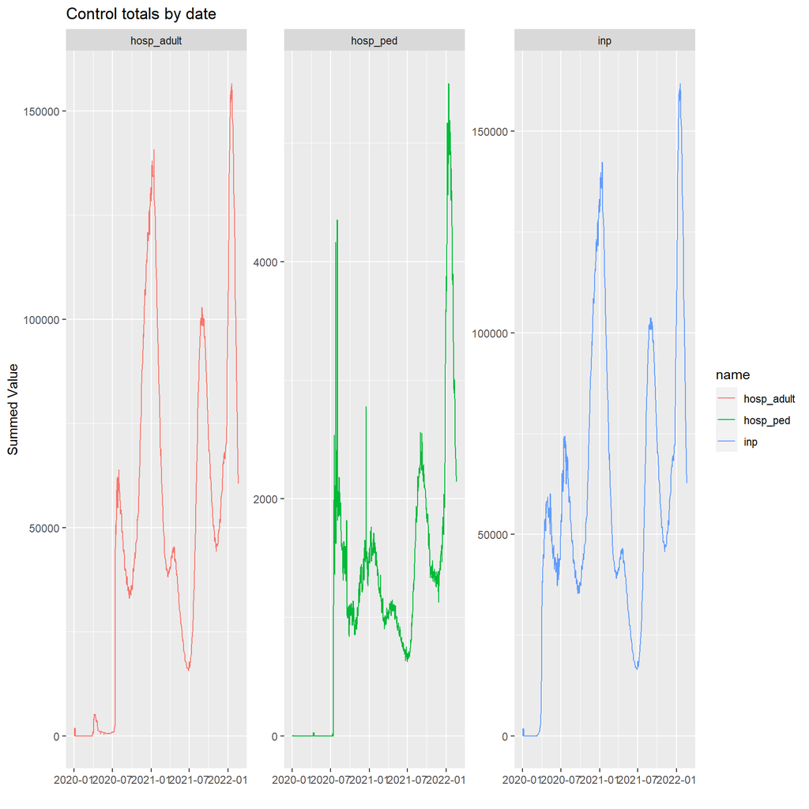

```
##
##
## Checking for similarity of: column names
## In reference but not in current:
## In current but not in reference:
##
## Checking for similarity of: date
## In reference but not in current: 0
## In current but not in reference: 15
##
## Checking for similarity of: state
## In reference but not in current:
## In current but not in reference:
```

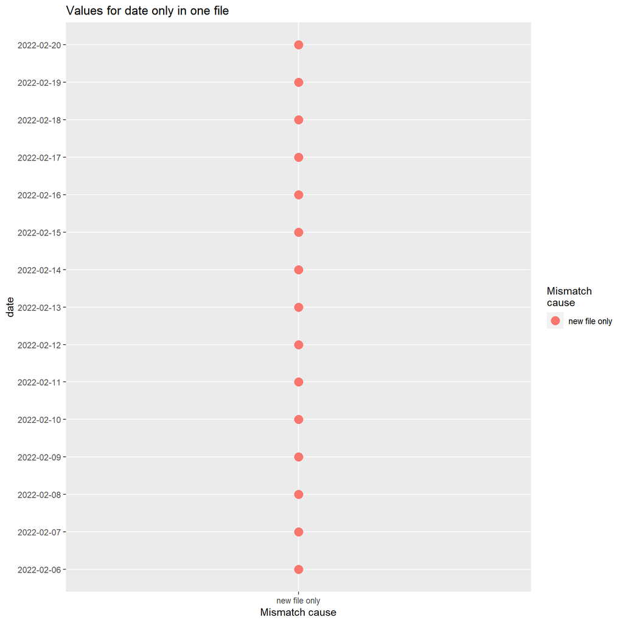

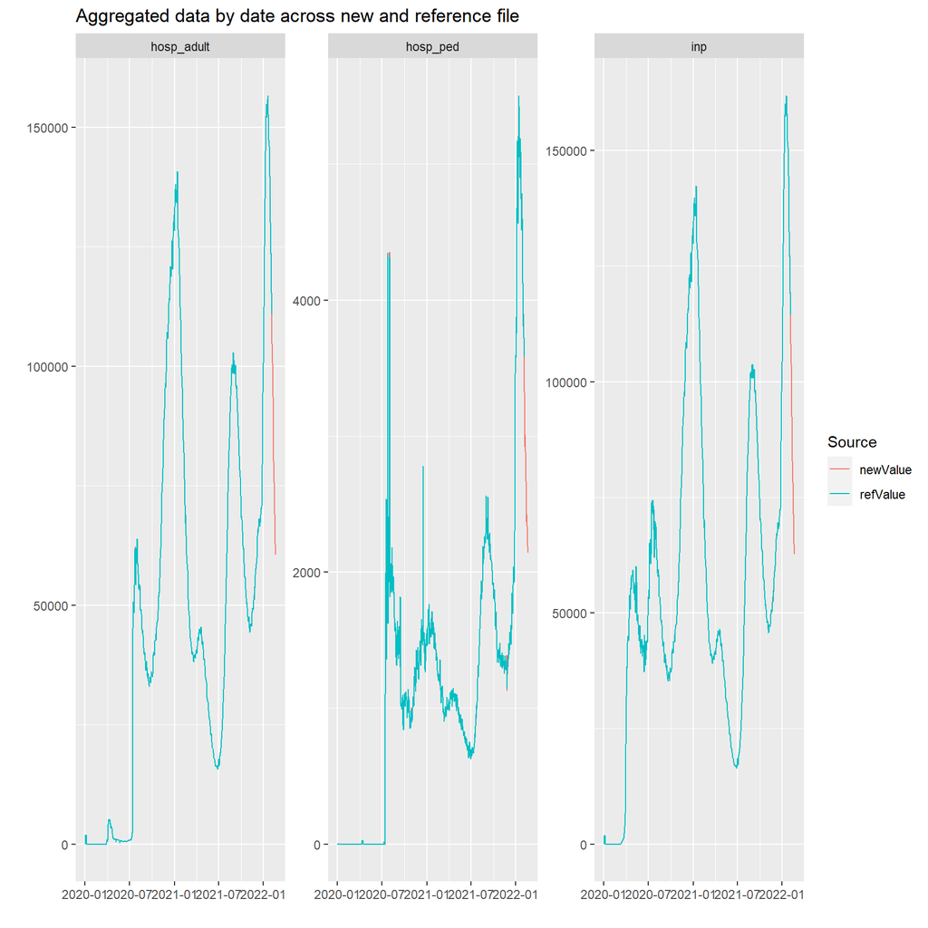

```
##
##
## ***Differences of at least 5 and at least 5%
##
##         date       name newValue refValue absDelta   pctDelta
## 1 2022-02-05        inp   108309   114478     6169 0.05538025
## 2 2022-02-05   hosp_ped     3323     3585      262 0.07585408
## 3 2021-11-24   hosp_ped     1387     1306       81 0.06015596
## 4 2022-02-05 hosp_adult   104794   110893     6099 0.05655417
```

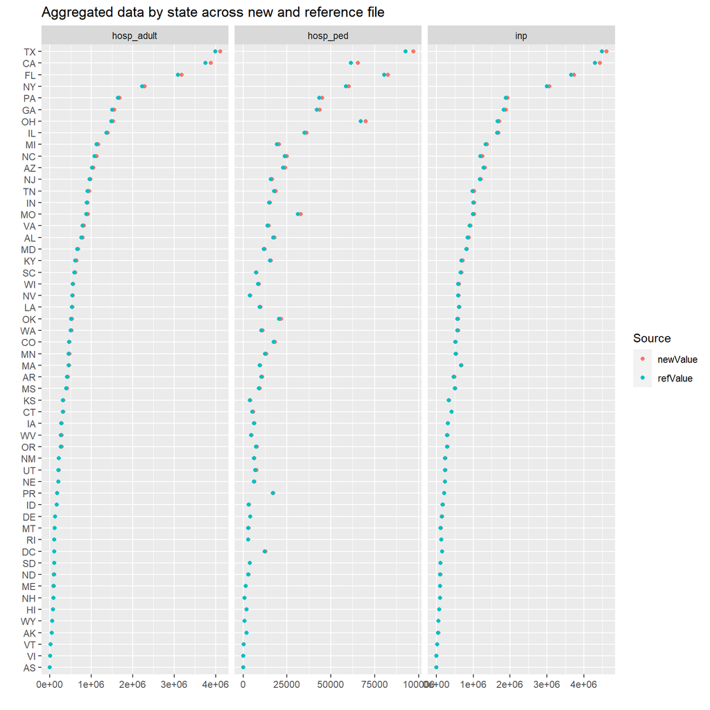

```
##
##
## ***Differences of at least 0 and at least 0.1%
##
##    state     name newValue refValue absDelta    pctDelta
## 1     NH hosp_ped      725      811       86 0.111979167
## 2     ME hosp_ped     1373     1431       58 0.041369472
## 3     WV hosp_ped     4435     4554      119 0.026476805
## 4     VT hosp_ped      348      357        9 0.025531915
## 5     AR hosp_ped    10602    10393      209 0.019909502
## 6     KS hosp_ped     3856     3929       73 0.018754014
## 7     SC hosp_ped     7275     7393      118 0.016089446
## 8     VI hosp_ped       81       80        1 0.012422360
## 9     MA hosp_ped     9296     9412      116 0.012401112
## 10    ID hosp_ped     3155     3120       35 0.011155378
```

[output cut: 149 more lines]

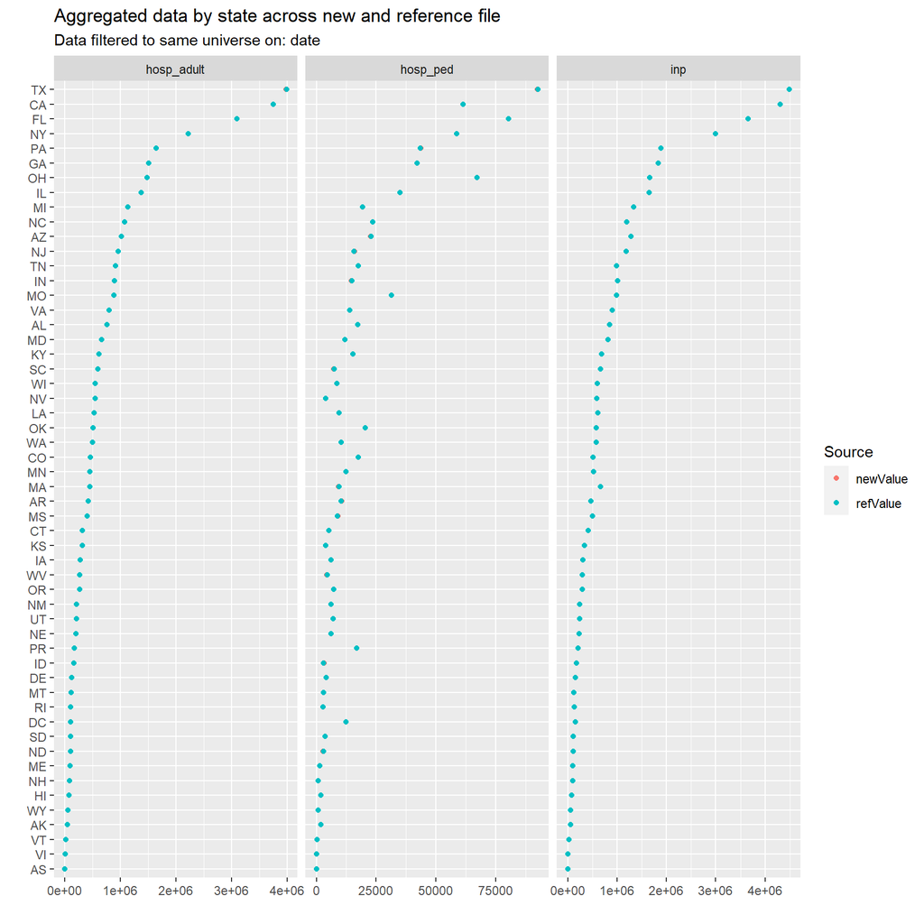

```
##
## *** File has been checked for uniqueness by: state date
```

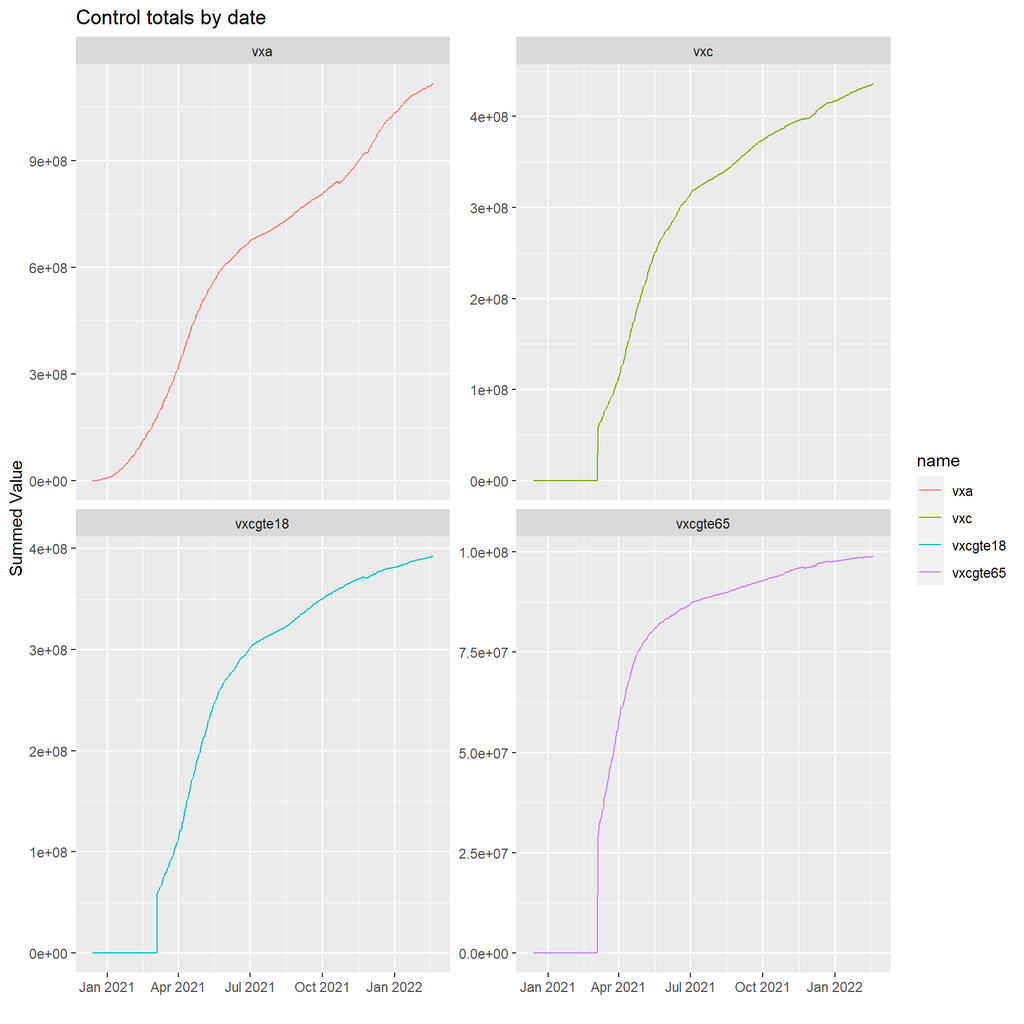

```
##
##
## Checking for similarity of: column names
## In reference but not in current:
## In current but not in reference:
##
## Checking for similarity of: date
## In reference but not in current: 0
## In current but not in reference: 14
##
## Checking for similarity of: state
## In reference but not in current:
## In current but not in reference:
```

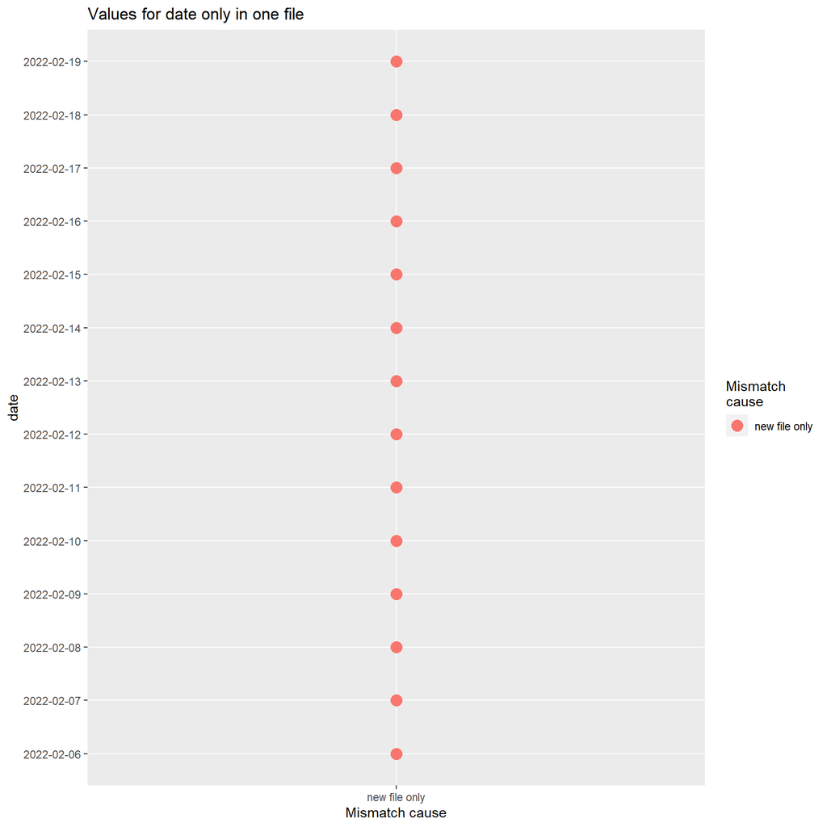

[6 more figures not shown]

```r
readList <- list("cdcDaily"="./RInputFiles/Coronavirus/CDC_dc_downloaded_220220.csv",
                 "cdcHosp"="./RInputFiles/Coronavirus/CDC_h_downloaded_220220.csv",
                 "vax"="./RInputFiles/Coronavirus/vaxData_downloaded_220220.csv"
                 )
compareList <- list("cdcDaily"=readFromRDS("cdc_daily_220206")$dfRaw$cdcDaily,
                    "cdcHosp"=readFromRDS("cdc_daily_220206")$dfRaw$cdcHosp,
                    "vax"=readFromRDS("cdc_daily_220206")$dfRaw$vax
                    )

cdc_daily_220220 <- readRunCDCDaily(thruLabel="Feb 18, 2022",
                                    downloadTo=lapply(readList, FUN=function(x) if(file.exists(x)) NA else x),
                                    readFrom=readList,
                                    compareFile=compareList,
                                    writeLog=NULL,
                                    useClusters=readFromRDS("cdc_daily_210528")$useClusters,
                                    weightedMeanAggs=c("tcpm7", "tdpm7", "cpm7", "dpm7", "hpm7",
                                                       "vxcpm7", "vxcgte65pct"
                                                       ),
                                    skipAssessmentPlots=FALSE,
                                    brewPalette="Paired"
                                    )
```

```r
saveToRDS(cdc_daily_220220, ovrWriteError=FALSE)
```

The latest hospital data are downloaded:

```r
# Run for latest data, save as RDS
indivHosp_20220221 <- downloadReadHospitalData(loc="./RInputFiles/Coronavirus/HHS_Hospital_20220221.csv")
```

[output not shown]

[output cut: 128 more lines]

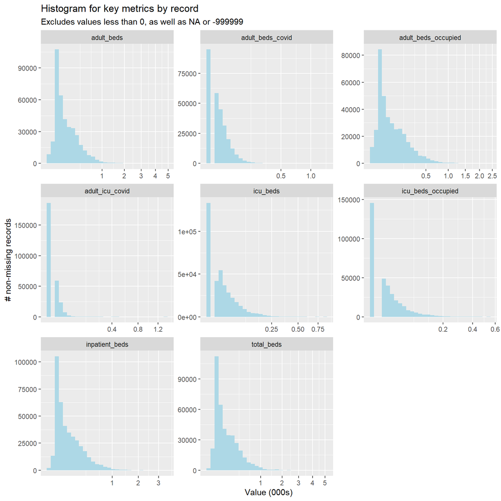

```r
saveToRDS(indivHosp_20220221, ovrWriteError=FALSE)
```